# Typst 功能速览与样例

## Typst 功能速览与样例

这份文档展示了 Typst 的功能以及在当前网页模板下的效果。上方是实际渲染效果，下方的代码块是对应的源代码。

注意

本文档不是详细的 Typst 教程。本文档的目的是展示各种 Typst 元素在当前模板下的渲染效果，顺带展示写法。

如果你之前从未接触过 Typst 和标记语言，建议先阅读 [Wiki 页面](https://github.com/Yousa-Mirage/Tufted-Blog-Template/wiki/Typst-%E5%BF%AB%E9%80%9F%E5%85%A5%E9%97%A8%E8%B5%84%E6%96%99) 及其中的资料，进行了解和学习后再来阅读本文档。

### 1. 字体与文本修饰

这里展示了 **粗体**、*斜体*、下划线、删除线、上划线、上标 E=mc<sup>2</sup>、下标 H<sub>2</sub>O。重要内容可以使用 高亮标记。

```
这里展示了 *粗体*、_斜体_、#underline[下划线]、#strike[删除线]、#overline[上划线]、上标 E=mc#super[2]、下标 H#sub[2]O。重要内容可以使用 #highlight[高亮标记]。
```

你可以通过空行来实现分段。

这是新的一段。你可以通过在行末添加`\`来实现换行。  
这是新的一行。

```
你可以通过空行来实现分段。

这是新的一段。你可以通过在行末添加`\`来实现换行。\
这是新的一行。
```

如果要显示特殊字符，需要转义：* _ # $ @

```
如果要显示特殊字符，需要转义：\* \_ \# \$ \@
```

网站的视觉外观由 CSS 控制，你目前不能在 Typst 中直接改变文字的 颜色、大小 或 字体 等样式。

```
网站的视觉外观由 CSS 控制，你目前不能在 Typst 中直接改变文字的 #text(fill: blue)[颜色]、#text(size: 14pt)[大小] 或 #text(font: "Liu Jian Mao Cao")[字体] 等样式。
```

### 2. 多级标题

开头的“Typst 功能速览与样例文档”是一级标题，上面的 “2. 多级标题” 是二级标题。

#### 三级标题

##### 四级标题

```
=== 三级标题
==== 四级标题
```

### 3. 链接

你可以使用 `#link()` 函数添加链接，例如：

- [这是一个外部网页的链接](https://github.com/Yousa-Mirage)。
- [这也是一个外部链接](https://yousa-mirage.github.io/)。
- 你也可以链接到本网站的其他位置，例如：
  - 这是一个指向 PDF 文档的链接。你可以创建编译为 PDF 的 Typst 文档，例如这个 PDF 由名为 `sample-PDF.typ` 的文件编译而来。你可以链接到编译的 PDF 文件，从而展示带有复杂格式的 PDF 文档，比如 PDF 版简历。
  - 而这是一个指向本网站 CV 页的链接。

```
- #link("https://github.com/Yousa-Mirage")[这是一个外部网页的链接]。
- #link("https://yousa-mirage.github.io/", "这也是一个外部链接")。
- 你也可以链接到本网站的其他位置，例如：
  - #link("sample-PDF.pdf")[这是一个指向 PDF 文档的链接]。
  - #link("/CV/")[而这是一个指向本网站 CV 页的链接。]
```

### 4. 列表结构

这是一个混合列表的示例：

- 无序列表项 1
- 无序列表项 2
  - 支持缩进层级
    - 继续缩进
  1. 无序列表中可以插入有序列表

     在当前层级添加段落内容
1. 有序列表项 1
2. 有序列表项 2 (自动编号)
   1. 子有序列表 A
      - 有序列表中可以插入无序列表
   - 子无序列表 B

**术语列表**

带有名称的列表项，适合用于名词解释。

**Typst**

一个新的基于标记的排版系统。

```
- 无序列表项 1
- 无序列表项 2
  - 支持缩进层级
    - 继续缩进
  + 无序列表中可以插入有序列表

    在当前层级添加段落内容

+ 有序列表项 1
+ 有序列表项 2 (自动编号)
  + 子有序列表 A
    - 有序列表中可以插入无序列表
  - 子无序列表 B

/ 术语列表: 带有名称的列表项，适合用于名词解释。
/ Typst: 一个新的基于标记的排版系统。
```

### 5. 边栏、注释和参考文献

你可以在任何地方添加边栏内容。

**Tufte 样式**最鲜明的特点就是采用**宽大的侧边栏布局**，将注释、参考文献和图表直接并排展示在正文旁，取代了传统的脚注或尾注，在数字屏幕上复刻了经典学术著作般清晰、沉浸且图文对照的深度阅读体验。<sup>1</sup>

这是本网站首页写的话。

你可以使用 `footnote()` 函数添加注释，会自动添加到与正文齐平的侧边栏中，不需要再翻到网站末尾。<sup>2</sup>

脚注真的很打断阅读体验！这也是我使用 Tufte 样式制作博客模板的原因。

```
你可以使用 `footnote()` 函数添加注释。#footnote[脚注真的很打断阅读体验！]
```

你可以使用 `tufted.margin-note()` 函数在任何地方添加任意的**不分段的**边栏内容。例如，你可以添加一行文本图片、行内代码、行内公式等<sup>3</sup>。

`box()` 函数可以将内容设置在一段内。

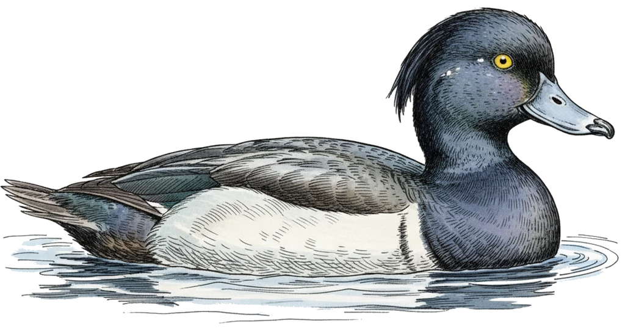

```
// 这是设置右侧图片和文本的 Typst 代码。
#tufted.margin-note[
  #image("../../imgs/tufted-duck-male.webp")
]
#tufted.margin-note[
  ⬆️这是一只鸭，这是 `一个行内代码`，这是一个行内公式 $1 + 1 = 2$。\
  这是换行文本
]
```

你可以将参考文献导出为 `.bib` 文件，使用 `bibliography()` 函数将其引用到 Typst中，然后就可以使用 `@` 引用它，就像这样(Tufte, 1973)。  
默认会将使用的参考文献显示在调用 `bibliography()` 函数的位置。模板暂时不支持自动将参考文献展示在边栏中，但你可以手动引用<sup>4</sup>。

Tufte, E. R. (1973). The Relationship between Seats and Votes in Two-Party Systems. *American Political Science Review, 67*(2), 540～554. https://doi.org/10.2307/1958782

- Tufte, E. R. (1973). The Relationship between Seats and Votes in Two-Party Systems. *American Political Science Review*, *67*(2), 540～554. https://doi.org/10.2307/1958782

```
然后就可以使用 `@` 引用它，就像这样@tufte1973relationship。
你可以手动引用#footnote[Tufte, E. R. (1973). The Relationship between Seats and Votes in Two-Party Systems. _American Political Science Review, 67_(2), 540～554. https://doi.org/10.2307/1958782]。

#bibliography("papers.bib", title: none, style: "american-psychological-association")
```

你甚至可以编写一个 `for` 循环来手动展示 `.bib` 中的文献内容并进行排版：

- Tufte, Edward R., “Determinants of the Outcomes of Midterm Congressional Elections,” *American Political Science Review*, 1975. DOI: 10.2307/1958391
- Tufte, Edward R., “The Relationship between Seats and Votes in Two-Party Systems,” *American Political Science Review*, 1973. DOI: 10.2307/1958782

```
#import "@preview/citegeist:0.2.0": load-bibliography

#{
  let bib = load-bibliography(read("papers.bib"))
  for item in bib.values().rev() [
    #let data = item.fields
    - #data.author, "#data.title," #emph(data.journal), #data.year. DOI: #link(data.url)[#data.doi]
  ]
}
```

你可以使用 `tufted.full-width()` 将内容以全宽度展现出来，例如这是一张超长的 MIKU：

[figure not shown]

```
#tufted.full-width[#image("miku.png")]
```

### 6. 图片

你可以使用 `figure()` 函数来为任意的内容添加标题信息，特别是图片和表格，这也会显示在侧边栏中。

使用 `image()` 函数可以添加图片，使用 `width`、`height` 参数可以控制大小，例如 `figure + image`：

图 1 这也是鸭鸭。

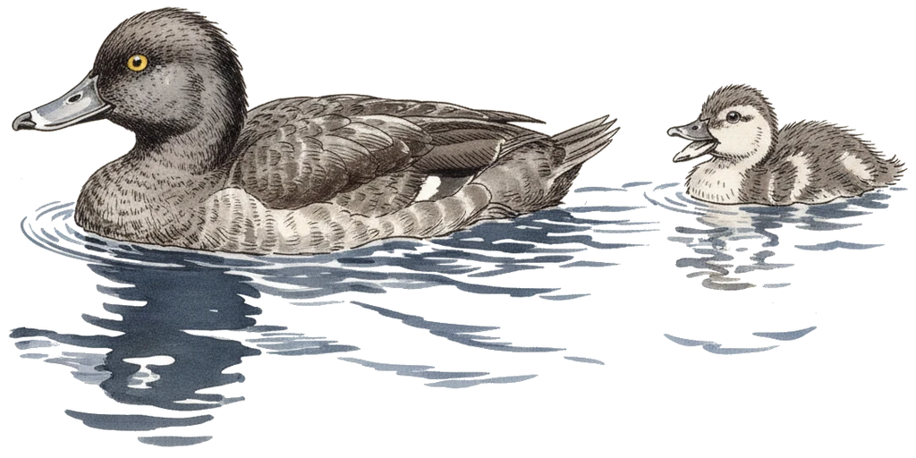

图 2 这是只猴！

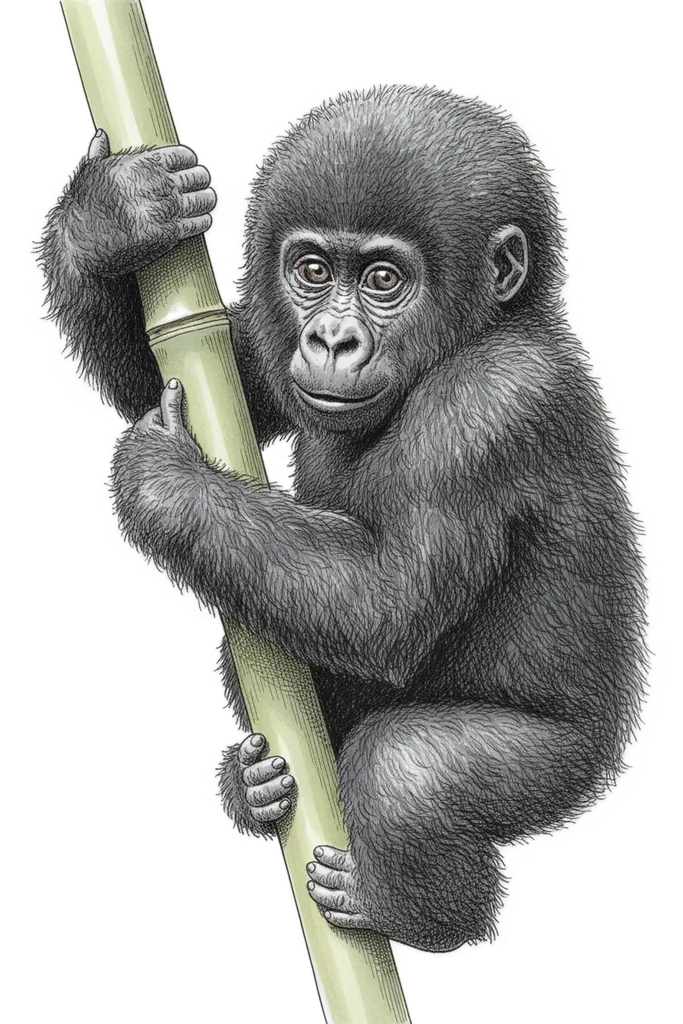

```
#figure(caption: "这也是鸭鸭。")[
  #image("../../imgs/tufted-duck-female-with-duckling.webp", width: 250pt)
]

#figure(caption: "这是只猴！")[
  #image("../../imgs/gorilla.webp", height: 250pt)
]
```

### 7. 表格

HTML 导出还不支持调整列宽、表格样式等，甚至目前连边框都没有。现在推荐直接添加 PDF 或表格图片。

你可以使用 `table()` 函数创建简单的表格：

表 1 `table()` 函数生成的表格

| **姓名** | **简介** | **状态** |
| --- | --- | --- |
| Alice | 前端开发者，喜欢 Rust | 在线 |
| Bob | 后端工程师，喜欢 Python | 离线 |

```
#figure(caption: [`table()` 函数生成的表格])[
  #table(
    columns:(1fr, 2fr, auto),
    [*姓名*], [*简介*], [*状态*],
    [Alice], [前端开发者，喜欢 Rust], [在线],
    [Bob], [后端工程师，喜欢 Python], [离线],
  )
]
```

更推荐使用橘子大佬写的 `tablem` 包，根据 markdown 表格格式生成表格：

| **Name** | **Location** | **Height** | **Score** |
| --- | --- | --- | --- |
| John | Second St. | 180 cm | 5 |
| Wally | Third Av. | 160 cm | 10 |

```
#import "@preview/tablem:0.3.0": *

#tablem[
  | *Name* | *Location* | *Height* | *Score* |
  | :----: | :--------: | :------: | :-----: |
  | John   | Second St. | 180 cm   | 5       |
  | Wally  | Third Av.  | 160 cm   | 10      |
]
```

### 8. 代码块

使用 `` ``` `` 包裹代码来添加代码块，支持语法高亮，也可以和图片、表格一样使用 `figure()` 添加标题。我修改了代码块样式，并添加了行号和复制按钮。

代码 1 我会 Python。

```
# Python 中的斐波那契函数
def fib(n):
    if n <= 1: return n
    return fib(n-1) + fib(n-2)
```

代码 2 我最近在学习 Rust。

[output not shown]

上述 Rust 代码块对应的 Typst 源代码如下：

````
#figure(caption: "我最近在学习 Rust。")[
  ```rs
  fn main() {
      println!("Hello, Typst!");
  }
  ```
]
````

### 9. 对齐、分栏与段落块

目前 Typst 编译 HTML 还不支持段落对齐方式和分栏，但你可以在 PDF 中实现。这在简历、分栏论文、演示文稿中非常有用。

你可以使用同样是橘子大佬写的定理包 `theorion` 来实现各种特殊的段落样式，例如：

这是一个引用块。你可以在这里引用相当长的内容。你可以在这里引用相当长的内容。你可以在这里引用相当长的内容。你可以在这里引用相当长的内容。支持换行、分段，甚至可以在其中添加新的引用块。

这是引用块内部的引用块。

- 列表

`This is a code block.`

提示

这是一个提示块。

注意

这是一个注意块。

重要

这是一个强调块。

警告

这是一个警告块。

小心

这也是一个警告块。

```
#import "@preview/theorion:0.4.1": *

#quote-box[
  这是一个引用块。你可以在这里引用相当长的内容。你可以在这里引用相当长的内容。你可以在这里引用相当长的内容。你可以在这里引用相当长的内容。支持换行、分段，甚至可以在其中添加新的引用块。
  #quote-box[这是引用块内部的引用块。]
  - 列表
  `This is a code block.`
]
#tip-box[这是一个提示块。]
#note-box[这是一个注意块。]
#important-box[这是一个强调块。]
#warning-box[这是一个警告块。]
#caution-box[这也是一个警告块。]
```

### 10. 数学公式

目前 FireFox 浏览器显示公式可能存在问题。

Typst 使用 `$ $`包裹公式。行内公式嵌入在文字中，写法是 `$ $` 内紧跟公式内容，例如

[figure not shown]

。

```
$f(x) = x^2$
```

而块级公式独占一行，写法是 `$ $` 与公式内容之间存在空格，例如

[figure not shown]

```
$ A = pi r^2 $
```

包含分式、根号、求和与积分：

[figure not shown]

```
$ integral_0^infinity e^(-x^2) d x = sqrt(pi) / 2 $
$ sum_(k=0)^n k = 1 + ... + n = (n(n+1)) / 2 $
```

矩阵与行列式：

[figure not shown]

```
$
  mat(
    1, 2;
    3, 4
  ) dot vec(x, y) = vec(5, 6)
$
```

多行对齐公式：

图 3 多行对齐公式

[figure not shown]

```
#figure(caption: "多行对齐公式")[
  $
    f(x) & = (x + 1)^2 \
         & = x^2 + 2x + 1
  $
]
```

更加复杂的公式和符号写法可参考[官方文档](https://typst-doc-cn.github.io/docs/reference/math/)。

### 12. 编程特性

Typst 不但是一个标记排版语言，还是一门编程排版语言：

[output not shown]

```
#show "Latex": "Typst"
我爱 Latex!
```

我爱 Typst!

```
// 支持自定义函数
#let greet(name) = [Hello, #name!]
#greet("World")\
#greet("Yousa Mirage")
```

Hello, World!  
Hello, Yousa Mirage!

### 13. 嵌入 Markdown

你可以使用 `cmarker` 将 Markdown 内容嵌入到 Typst 文档中。这在将现有 Markdown 文件集成到基于 Typst 的网站时尤其有用。要渲染数学表达式，请使用 `mitex`。例如这段代码：

```
#import "@preview/cmarker:0.1.8"
#import "@preview/mitex:0.2.6": *

// 这个 scope 是必要的
// 参见 https://typst.app/universe/package/cmarker#resolving-paths-correctly
#let scope = (image: (source, alt: none, format: auto) => figure(image(source, alt: alt, format: format)))
#let md-content = read("tufted-titmouse.md")
#cmarker.render(md-content, math: mitex, scope: scope)
```

将 `"tufted-titmouse.md"` 渲染为以下内容：

### 灰胸山雀 The Tufted Titmouse

灰胸山雀（*Baeolophus bicolor*）是一种小巧活泼的鸣禽，原生于北美东部的落叶林。其显著特征包括独特的灰色羽冠、乌黑的大眼睛和两侧锈红色的羽毛。这些鸟类是灵巧的觅食者，也是后院喂食器的常客。冬季时，它们常与山雀和䴓组成混合鸟群活动。其鸣声清脆如哨音，似在反复鸣唱 “*peter-peter-peter*”。

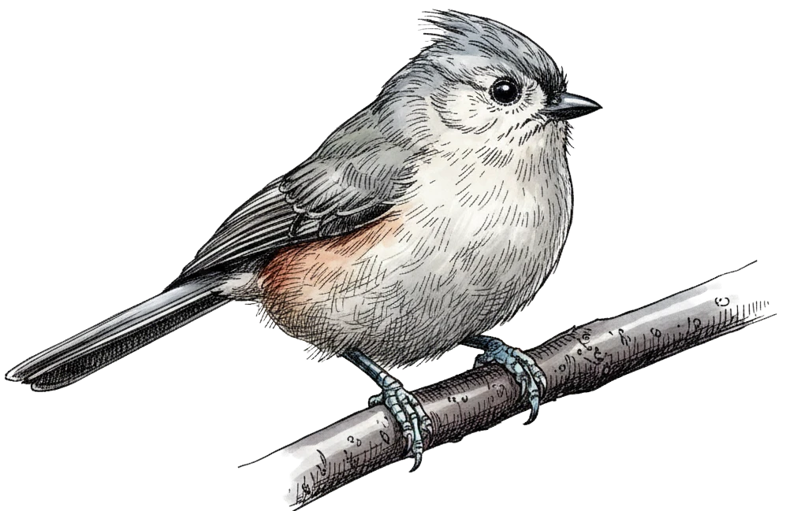

我们可以用 Logistic 增长方程来模拟它们的种群动态：

[figure not shown]

`"tufted-titmouse.md"` 渲染完毕。